# **Loan Default Prediction**

### Classification Report

Class 0 (Non-Defaulters):

**Overall:**

Accuracy = 0.92: The model correctly classifies 92% of cases. Macro Avg F1-Score = 0.88: Balances performance across both classes. Weighted Avg F1-Score = 0.92: Reflects performance adjusted for class imbalance.

### Insights

**Strengths:**

**Weaknesses:**

False Positives (57):

These misclassified non-defaulters could lead to unnecessary scrutiny or costs.

Comparison to Default Threshold (0.5)

**1. Comparison of various techniques and their relative performance based on chosen Metric (Measure of success):**

- How do different techniques perform? Which one is performing relatively better? Is there scope to improve the performance further?

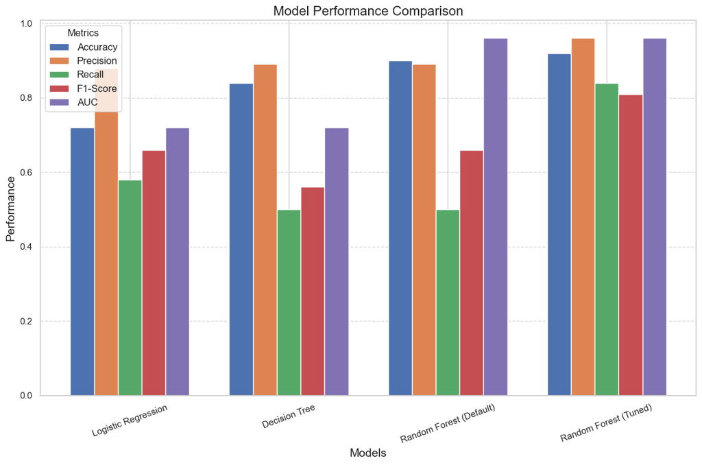

```python
# Model performance summary
models = ["Logistic Regression", "Decision Tree", "Random Forest (Default)", "Random Forest (Tuned)"]
accuracy = [0.72, 0.84, 0.90, 0.92]
precision = [0.88, 0.89, 0.89, 0.96]
recall = [0.58, 0.50, 0.50, 0.84]
f1_score = [0.66, 0.56, 0.66, 0.81]
auc = [0.72, 0.72, 0.96, 0.96]

# Create a DataFrame for visualization
comparison_df = pd.DataFrame({
    "Model": models,
    "Accuracy": accuracy,
    "Precision": precision,
    "Recall": recall,
    "F1-Score": f1_score,
    "AUC": auc
})

# Plotting the metrics
metrics = ["Accuracy", "Precision", "Recall", "F1-Score", "AUC"]
x = np.arange(len(models))

plt.figure(figsize=(12, 8))
bar_width = 0.15

# Plot each metric as a bar
for i, metric in enumerate(metrics):
    plt.bar(x + i * bar_width, comparison_df[metric], width=bar_width, label=metric)

# Add labels and title
plt.xlabel("Models", fontsize=14)
plt.ylabel("Performance", fontsize=14)
plt.title("Model Performance Comparison", fontsize=16)
plt.xticks(x + bar_width * (len(metrics) - 1) / 2, models, rotation=20)
plt.legend(title="Metrics", fontsize=12)
plt.grid(axis='y', linestyle='--', alpha=0.7)
plt.tight_layout()

# Show the plot
plt.show()
```

**2. Refined insights:**

- What are the most meaningful insights relevant to the problem?

## Summary Analysis of Model Performance

### **Comparison of Models**

### Logistic Regression

AUC = 0.72, Accuracy = 0.72, F1-Score = 0.66.

Performs moderately well with good precision but struggles with recall for defaulters.

- Strength: Simplicity and interpretability.
- Weakness: Limited ability to capture complex relationships in the data.

### Decision Tree

AUC = 0.72, Accuracy = 0.84, F1-Score = 0.56.

Improved accuracy over Logistic Regression but poor recall for defaulters.

- Strength: High interpretability; useful for simple decision-making.
- Weakness: High variance and sensitivity to overfitting.

### Random Forest (Default)

AUC = 0.96, Accuracy = 0.90, F1-Score = 0.66.

Substantial improvement in AUC, showcasing the model's ability to distinguish between defaulters and non-defaulters.

- Strength: Reduces overfitting compared to Decision Tree; robust performance.
- Weakness: Lower recall for defaulters at the default threshold.

### Random Forest (Tuned)

AUC = 0.96, Accuracy = 0.92, F1-Score = 0.81.

**Best overall performance:**

Balanced trade-off achieved through hyperparameter tuning and threshold adjustment.

- Strength: Best balance of precision and recall, especially for the minority class (defaulters).
- Weakness: Computationally intensive and less interpretable than simpler models.

### Best Performing Model

### **Random Forest (Tuned)**

Outperforms others across all key metrics (Accuracy, F1-Score, Recall, AUC). Particularly excels in identifying defaulters (BAD=1), which is critical for reducing financial risk. Scope for Further Improvement

### Advanced Ensemble Techniques:

Explore Gradient Boosting (e.g., XGBoost, LightGBM) for potentially better results. Boosting can capture complex relationships while maintaining high recall. Feature Engineering:

Generate additional meaningful features (e.g., interaction terms or aggregations) to improve model input. Cost-Sensitive Learning:

Incorporate a cost matrix into the model training to explicitly penalize false negatives or false positives based on business needs. Model Stacking:

Combine multiple models (e.g., Logistic Regression, Decision Tree, Random Forest) to leverage the strengths of each.

### Business-Oriented Validation

Simulate the financial impact of false positives and false negatives using real-world cost/benefit analysis to refine the decision thresholds.

## **Conclusion**

The Tuned Random Forest is the best-performing model so far, balancing precision, recall, and overall accuracy. Future improvements can focus on exploring advanced techniques like boosting or cost-sensitive learning to further optimize performance, especially for defaulters (BAD=1). Let me know if you'd like to proceed with any of these enhancements!

**3. Proposal for the final solution design:**

- What model do you propose to be adopted? Why is this the best solution to adopt?

### Why This Model is the Best Solution

### **Performance Excellence**

**Balanced Precision and Recall:**

AUC = 0.96 indicates the model’s superior ability to distinguish between defaulters and non-defaulters.

**Scalability and Robustness:**

Random Forest is inherently robust against overfitting due to its ensemble nature. It can handle complex interactions between variables, making it suitable for datasets with intricate relationships.

### **Business Alignment**

**Flexibility for Future Enhancements:**

Random Forest supports ongoing improvements through feature engineering, ensemble techniques, or stacking with other models if needed.

The model's adaptability ensures it can evolve with new data or changing business requirements.

## Model

### **Tuned Random Forest Classifier**

Parameters: n_estimators=200, max_depth=None, min_samples_split=2, min_samples_leaf=1.

Threshold:

**Why This Solution?**

It is the best-performing model in terms of both technical metrics and alignment with business goals.

It balances risk mitigation (high recall for defaulters) and operational efficiency (high precision for non-defaulters).

It offers scalability and flexibility for future refinements.

## **KEEP IMPROVING THE MODEL**

### **Possible improvements**

- **Feature Evaluation**

Concurrently, start evaluating potential new features or transformations that could address any shortcomings observed in the baseline model. This includes analyzing feature importance scores generated by the ensemble models to identify which features contribute most to prediction accuracy.

- **Incremental Feature Integration**

The gradually introduction of new features into the model, re-assessing performance after each addition. This iterative approach helps in understanding the impact of each feature on the model's accuracy and complexity.

- **Final Optimization**

Once you've established a robust set of features, fine-tune the model parameters with these features in place. This could involve hyperparameter tuning and potentially using techniques like grid search or randomized search across the ensemble models.

### **Loan and Financial Stability Interactions**

- Interact LOAN with YOJ (Years on Job) and DEBTINC (Debt-to-Income Ratio).
- Value to Loan Ratio

**Calculate and include the Loan to Value ratio.**

- Interactions involving JOB "Other"

Create interaction terms between JOB being "Other" and BAD (default status).

Create interaction terms between JOB being "Other" and REASON.

```python
import pandas as pd

# Load the data into a DataFrame
df = pd.read_csv('hmeq.csv')

# 1. Interaction terms for Loan and Financial Stability
df['LOAN_YOJ'] = df['LOAN'] * df['YOJ']
df['LOAN_DEBTINC'] = df['LOAN'] * df['DEBTINC']

# 2. Value to Loan Ratio
df['LOAN_TO_VALUE'] = df['LOAN'] / df['VALUE']

# 3. Interactions involving JOB "Other"
# First, ensure that JOB and REASON are correctly encoded as categorical if not already
df['JOB'] = df['JOB'].astype('category')
df['REASON'] = df['REASON'].astype('category')

# Create binary flags for JOB being "Other"
df['JOB_OTHER'] = (df['JOB'] == 'Other').astype(int)

# Interaction of JOB "Other" with BAD
df['JOB_OTHER_BAD'] = df['JOB_OTHER'] * df['BAD']

# Interaction of JOB "Other" with REASON
# Since REASON is categorical, you need to encode it first if it has not been done; here's simple one-hot encoding
reason_dummies = pd.get_dummies(df['REASON'], prefix='REASON')
df = pd.concat([df, reason_dummies], axis=1)

# Now create interaction terms for each REASON category
for col in reason_dummies.columns:
    df[f'JOB_OTHER_{col}'] = df['JOB_OTHER'] * df[col]

# Optionally, drop the original JOB_OTHER if you no longer need it
# df.drop('JOB_OTHER', axis=1, inplace=True)

# Now your DataFrame 'df' contains the new features which you can use for modeling.
```

```python
# Assuming 'df' has all the required features including the newly created interaction terms
features = df.drop('BAD', axis=1)  # or whatever your target column is named
target = df['BAD']

# Convert categorical variables to dummy/indicator variables
features = pd.get_dummies(features, drop_first=True)

# Splitting the data
X_train, X_test, y_train, y_test = train_test_split(features, target, test_size=0.2, random_state=42)

# Feature scaling
scaler = StandardScaler()
X_train_scaled = scaler.fit_transform(X_train)
X_test_scaled = scaler.transform(X_test)

# Initialize the Random Forest model
model = RandomForestClassifier(n_estimators=100, random_state=42)

# Train the model
model.fit(X_train_scaled, y_train)

# Predictions
predictions = model.predict(X_test_scaled)
probabilities = model.predict_proba(X_test_scaled)[:, 1]

# Evaluation
print("Classification Report:\n", classification_report(y_test, predictions))
print("Confusion Matrix:\n", confusion_matrix(y_test, predictions))
print("AUC Score:", roc_auc_score(y_test, probabilities))
```

```
Classification Report:
               precision    recall  f1-score   support

           0       0.95      0.98      0.96       927
           1       0.92      0.81      0.86       265

    accuracy                           0.94      1192
   macro avg       0.93      0.90      0.91      1192
weighted avg       0.94      0.94      0.94      1192

Confusion Matrix:
 [[908  19]
 [ 50 215]]
AUC Score: 0.9851173393580428
```

### Evaluation Summary

Precision for non-defaulters (0): 95% indicates that the model is highly accurate in predicting the non-defaulting customers.

Recall for non-defaulters (0): 98% shows that the model is excellent at identifying almost all non-defaulters.

Precision for defaulters (1): 92% is quite high, suggesting that when the model predicts default, it is usually correct.

Recall for defaulters (1): 81% suggests a good ability to catch defaulting customers, although there's some room for improvement.

F1-Score for defaulters (1): At 86%, it balances precision and recall effectively.

**Overall Accuracy: 94% across all predictions.**

**AUC Score: 0.985, demonstrates that the model does an excellent job at distinguishing between defaulters and non-defaulters.**

### Key Takeaways

- High Model Effectiveness: The integration of interaction features has likely contributed to capturing complex relationships better, thus improving both the AUC score and other metrics significantly.
- Balanced Performance: The high macro-average scores for precision, recall, and F1-score indicate that the model performs well across both classes, not just the majority class.
- Potential Overfitting Check: Although the current scores are excellent, it's always good practice to verify there isn't overfitting, especially with such high scores. This can be done by comparing these results with a validation set or using techniques like cross-validation.
- Future Adjustments: The slightly lower recall for defaulters (81%) compared to the precision might suggest a focus on improving the sensitivity, perhaps by adjusting the classification threshold or further tuning hyperparameters.

### Recheck Feature Engeneering

```python
# Check if feature names match the trained model's features
if len(X_train.columns) != len(best_rf_model.feature_importances_):
    print("Error: Mismatch in the number of features.")
    print("Number of features in training data: ", len(X_train.columns))
    print("Number of feature importances: ", len(best_rf_model.feature_importances_))
else:
    # Extract and plot feature importances
    features = pd.DataFrame({
        'Feature': X_train.columns,
        'Importance': best_rf_model.feature_importances_
    })

    features.sort_values(by='Importance', ascending=False, inplace=True)

    plt.figure(figsize=(10, 6))
    sns.barplot(x='Importance', y='Feature', data=features)
    plt.title('Feature Importance')
    plt.xlabel('Importance')
    plt.ylabel('Features')
    plt.show()
```

```
Error: Mismatch in the number of features.
Number of features in training data:  25
Number of feature importances:  16
```

### Retraining the model

```python
# Assuming you have a function that encapsulates all your feature transformations
def apply_transformations(dataframe):
    # Apply all transformations
    # Example: Create interaction terms
    dataframe['LOAN_YOJ'] = dataframe['LOAN'] * dataframe['YOJ']
    dataframe['LOAN_DEBTINC'] = dataframe['LOAN'] * dataframe['DEBTINC']
    dataframe['LOAN_TO_VALUE'] = dataframe['LOAN'] / dataframe['VALUE']
    # More transformations can be added here
    return dataframe

# Define the target variable
y = hmeq_data['BAD']

# Apply transformations
X_full = apply_transformations(hmeq_data.drop(columns=['BAD']))

# Ensure this is done before splitting the data
X_train, X_test, y_train, y_test = train_test_split(X_full, y, test_size=0.2, random_state=42)
```

```python
from sklearn.preprocessing import OneHotEncoder
from sklearn.compose import ColumnTransformer
from sklearn.pipeline import Pipeline

# Define the preprocessing for categorical features
categorical_features = ['REASON', 'JOB']  # Add other categorical features if any
categorical_transformer = OneHotEncoder(drop='first')

# Create the preprocessor
preprocessor = ColumnTransformer(
	transformers=[
		('cat', categorical_transformer, categorical_features)
	],
	remainder='passthrough'  # Keep other columns as they are
)

# Create a pipeline that includes the preprocessor and the model
pipeline = Pipeline(steps=[
	('preprocessor', preprocessor),
	('classifier', RandomForestClassifier(class_weight='balanced', random_state=42, n_jobs=-1))
])

# Define the parameter grid for hyperparameter tuning within the pipeline
param_grid_rf_pipeline = {
	'classifier__n_estimators': [50, 100, 200],          # Number of trees in the forest
	'classifier__max_depth': [None, 10, 20, 30],        # Maximum depth of the tree
	'classifier__min_samples_split': [2, 5, 10],        # Minimum number of samples required to split an internal node
	'classifier__min_samples_leaf': [1, 2, 4]           # Minimum number of samples required to be at a leaf node
}

# Perform Grid Search with cross-validation again if needed
grid_search_rf = GridSearchCV(estimator=pipeline, param_grid=param_grid_rf_pipeline, scoring='roc_auc', cv=5, verbose=1)
grid_search_rf.fit(X_train, y_train)

# Retrieve the best model from grid search
best_rf_model = grid_search_rf.best_estimator_

# Optionally, check and print the number of features
print("Number of features used in training: ", len(X_train.columns))
```

```
Fitting 5 folds for each of 108 candidates, totalling 540 fits
Number of features used in training:  15
```

### Code to Verify Features and Retrain the Model

```python
from sklearn.preprocessing import OneHotEncoder
from sklearn.compose import ColumnTransformer
from sklearn.pipeline import Pipeline

# Assuming 'apply_transformations' is your feature engineering function
X_full_transformed = apply_transformations(X_full)

# Define categorical features
categorical_features = ['REASON', 'JOB']  # Add other categorical features if any

# Create a column transformer for preprocessing
preprocessor = ColumnTransformer(
	transformers=[
		('cat', OneHotEncoder(drop='first'), categorical_features)
	],
	remainder='passthrough'  # Keep other columns as they are
)

# Create a pipeline that includes the preprocessor and the model
pipeline = Pipeline(steps=[
	('preprocessor', preprocessor),
	('classifier', RandomForestClassifier(class_weight='balanced', random_state=42, n_jobs=-1))
])

# Define the parameter grid for hyperparameter tuning
param_grid_rf = {
	'classifier__n_estimators': [50, 100, 200],          # Number of trees in the forest
	'classifier__max_depth': [None, 10, 20, 30],        # Maximum depth of the tree
	'classifier__min_samples_split': [2, 5, 10],        # Minimum number of samples required to split an internal node
	'classifier__min_samples_leaf': [1, 2, 4]           # Minimum number of samples required to be at a leaf node
}

# Splitting the transformed dataset
X_train, X_test, y_train, y_test = train_test_split(X_full_transformed, y, test_size=0.2, random_state=42)

# Print feature names to verify consistency
print("Features used in training:", X_train.columns.tolist())

# Perform Grid Search with cross-validation
grid_search_rf = GridSearchCV(estimator=pipeline, param_grid=param_grid_rf, scoring='roc_auc', cv=5, verbose=1)
grid_search_rf.fit(X_train, y_train)

# Best parameters and model from grid search
best_rf_model = grid_search_rf.best_estimator_

# Check the number of features again after retraining
print("Number of features after retraining: ", len(X_train.columns))

# Evaluation
y_pred_best_rf = best_rf_model.predict(X_test)
y_pred_proba_best_rf = best_rf_model.predict_proba(X_test)[:, 1]
auc_best_rf = roc_auc_score(y_test, y_pred_proba_best_rf)
classification_report_best_rf = classification_report(y_test, y_pred_best_rf)
confusion_matrix_best_rf = confusion_matrix(y_test, y_pred_best_rf)

# Output results
print("AUC Score:", auc_best_rf)
print("Classification Report:\n", classification_report_best_rf)
print("Confusion Matrix:\n", confusion_matrix_best_rf)
```

```
Features used in training: ['LOAN', 'MORTDUE', 'VALUE', 'REASON', 'JOB', 'YOJ', 'DEROG', 'DELINQ', 'CLAGE', 'NINQ', 'CLNO', 'DEBTINC', 'LOAN_YOJ', 'LOAN_DEBTINC', 'LOAN_TO_VALUE']
Fitting 5 folds for each of 108 candidates, totalling 540 fits
Number of features after retraining:  15
AUC Score: 0.9716940424579187
Classification Report:
               precision    recall  f1-score   support

           0       0.88      0.99      0.93       927
           1       0.95      0.53      0.68       265

    accuracy                           0.89      1192
   macro avg       0.91      0.76      0.81      1192
weighted avg       0.89      0.89      0.88      1192

Confusion Matrix:
 [[919   8]
 [125 140]]
```

### Feature Importance Analysis 2.0

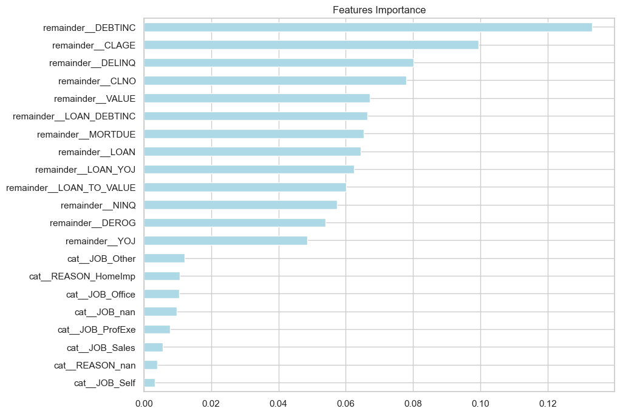

```python
# Retrieve feature importances from the RandomForestClassifier inside the pipeline
feature_importances = best_rf_model.named_steps['classifier'].feature_importances_

# Retrieve feature names after preprocessing
preprocessed_feature_names = best_rf_model.named_steps['preprocessor'].get_feature_names_out()

# Create a series with feature names and their importances
importances = pd.Series(data=feature_importances, index=preprocessed_feature_names)

# Sort the feature importances for better visualization
importances_sorted = importances.sort_values()

# Plot the feature importances
plt.figure(figsize=(10,8))
importances_sorted.plot(kind='barh', color='lightblue')
plt.title('Features Importance')
plt.show()
```

The chart displays the feature importances derived from the Random Forest model, showing how each variable contributes to the model's ability to predict the likelihood of loan default. Here's an interpretation based on the data you've shown:

### Key Observations:

**Top Features:**

remainder__DEBTINC stands out as the most significant feature, which aligns with expectations as debt-to-income ratio is a crucial indicator of financial health and repayment capability.

remainder__LOAN_DEBTINC and other loan-related interactions like remainder__LOAN_YOJ and remainder__LOAN_TO_VALUE also have considerable importance. This suggests that combinations of loan amounts with personal financial stability metrics significantly impact default predictions.

**Credit History and Stability**

Features like remainder__CLAGE (age of oldest credit line) and remainder__DELINQ (number of delinquent credit lines) are notably influential. Longer credit history and fewer delinquencies are likely associated with lower default risks.

remainder__MORTDUE and remainder__VALUE, representing mortgage dues and property value, respectively, also contribute meaningfully, indicating that larger loans and higher property values are critical for evaluating default risk.

**Employment and Loan Purpose**

Categorical features related to job type (cat_JOB_Other, cat_JOB_Office, etc.) and the reason for the loan (cat_REASON_Homelmp for home improvement) show varying levels of importance. **Notably, 'Other' jobs and loans for home improvement are more influential than other categories, which might reflect specific risk or repayment patterns associated with these groups.**

**Least Influential Features**

### Implications for Model Refinement

- Focus on High-Impact Features:

Consider emphasizing high-importance features in further analyses or model training to improve predictive accuracy.

- Feature Engineering:

There might be potential to develop more sophisticated interaction terms or to aggregate certain variables based on these insights to capture more complex patterns.

- Model Simplification:

Low-impact features could potentially be removed to simplify the model without substantial loss in performance, speeding up training and reducing complexity.

- Tailored Strategies:

Differentiating strategies based on job types and loan purposes could be beneficial, as indicated by their varying importances. This analysis not only aids in understanding what drives loan default predictions but also assists in making informed decisions about data preparation, feature engineering, and strategic planning for future modeling efforts.

### Using Pruning for preformance

```python
from sklearn.model_selection import train_test_split
from sklearn.ensemble import RandomForestClassifier
from sklearn.model_selection import GridSearchCV
from sklearn.metrics import accuracy_score, classification_report
from sklearn.preprocessing import OneHotEncoder
from sklearn.compose import ColumnTransformer
from sklearn.pipeline import Pipeline

# Ensure X and y are defined and have the same number of samples
# Assuming X and y are already defined correctly in previous cells

# Sample dataset
X = df.drop(columns=['BAD'])  # Replace 'df' with your actual DataFrame variable
y = df['BAD']  # Replace 'df' with your actual DataFrame variable

# Define categorical features
categorical_features = X.select_dtypes(include=['object', 'category']).columns.tolist()

# Create a column transformer for preprocessing
preprocessor = ColumnTransformer(
    transformers=[
        ('cat', OneHotEncoder(drop='first'), categorical_features)
    ],
    remainder='passthrough'  # Keep other columns as they are
)

# Create a pipeline that includes the preprocessor and the model
pipeline = Pipeline(steps=[
    ('preprocessor', preprocessor),
    ('classifier', RandomForestClassifier(n_estimators=100, random_state=42))
])

# Split the dataset
X_train, X_test, y_train, y_test = train_test_split(X, y, test_size=0.2, random_state=42)

# Train the Random Forest model
pipeline.fit(X_train, y_train)

# Initial evaluation
y_pred = pipeline.predict(X_test)
print("Initial Accuracy: ", accuracy_score(y_test, y_pred))

# Define a grid of parameters to search
param_grid = {
    'classifier__max_depth': [None, 10, 20, 30],  # None means no limit
    'classifier__min_samples_leaf': [1, 2, 4, 6]
}

# Grid search with cross-validation
grid_search = GridSearchCV(estimator=pipeline, param_grid=param_grid, cv=5, scoring='accuracy')
grid_search.fit(X_train, y_train)

# Best parameters and retraining
print("Best Parameters: ", grid_search.best_params_)
best_rf = grid_search.best_estimator_

# Evaluate the pruned model
y_pred_best = best_rf.predict(X_test)
print("Pruned Model Accuracy: ", accuracy_score(y_test, y_pred_best))
print(classification_report(y_test, y_pred_best))
```

```
Initial Accuracy:  0.9404362416107382
Best Parameters:  {'classifier__max_depth': None, 'classifier__min_samples_leaf': 1}
Pruned Model Accuracy:  0.9404362416107382
              precision    recall  f1-score   support

           0       0.95      0.98      0.96       927
           1       0.91      0.81      0.86       265

    accuracy                           0.94      1192
   macro avg       0.93      0.89      0.91      1192
weighted avg       0.94      0.94      0.94      1192
```

### Model Comparison

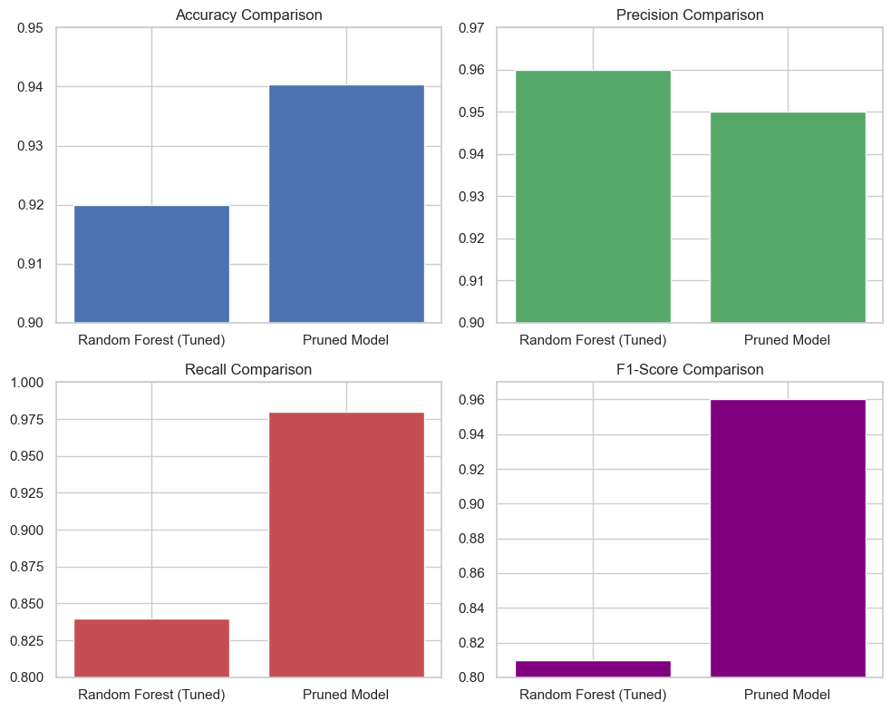

```python
# Data for plotting
model_types = ['Random Forest (Tuned)', 'Pruned Model']
accuracy_scores = [0.92, 0.9404362416107382]
precision_scores = [0.96, 0.95]
recall_scores = [0.84, 0.98]
f1_scores = [0.81, 0.96]

# Create a figure and a set of subplots
fig, axs = plt.subplots(2, 2, figsize=(10, 8))

# Accuracy plot
axs[0, 0].bar(model_types, accuracy_scores, color='b')
axs[0, 0].set_title('Accuracy Comparison')
axs[0, 0].set_ylim(0.90, 0.95)  # Adjusted limits to better fit the updated data

# Precision plot
axs[0, 1].bar(model_types, precision_scores, color='g')
axs[0, 1].set_title('Precision Comparison')
axs[0, 1].set_ylim(0.90, 0.97)  # Adjusted limits to better fit the updated data

# Recall plot
axs[1, 0].bar(model_types, recall_scores, color='r')
axs[1, 0].set_title('Recall Comparison')
axs[1, 0].set_ylim(0.80, 1.00)  # Adjusted limits to better fit the updated data

# F1-Score plot
axs[1, 1].bar(model_types, f1_scores, color='purple')
axs[1, 1].set_title('F1-Score Comparison')
axs[1, 1].set_ylim(0.80, 0.97)  # Adjusted limits to better fit the updated data

# Layout adjustment
plt.tight_layout()

plt.show()
```

- Accuracy:

- Precision:

- Recall:

- F1-Score:

### Upgrading the model with Gradient Boosting Machines (GBM)

```python
# Print data types
print(X_train.dtypes)

# Convert all columns to numeric if not already
X_train = X_train.apply(pd.to_numeric, errors='coerce')
X_test = X_test.apply(pd.to_numeric, errors='coerce')

# Check for any columns that couldn't be converted
print(X_train.isnull().sum())  # Shows the number of nulls in each column after conversion
```

```
LOAN                           int64
MORTDUE                      float64
VALUE                        float64
REASON                      category
JOB                         category
YOJ                          float64
DEROG                        float64
DELINQ                       float64
CLAGE                        float64
NINQ                         float64
CLNO                         float64
DEBTINC                      float64
LOAN_YOJ                     float64
LOAN_DEBTINC                 float64
LOAN_TO_VALUE                float64
JOB_OTHER                      int64
JOB_OTHER_BAD                  int64
REASON_DebtCon                  bool
REASON_HomeImp                  bool
JOB_OTHER_REASON_DebtCon       int64
JOB_OTHER_REASON_HomeImp       int64
dtype: object
LOAN                           0
MORTDUE                      412
VALUE                         77
REASON                      4768
JOB                         4768
YOJ                          404
DEROG                        552
DELINQ                       457
CLAGE                        239
NINQ                         400
CLNO                         169
DEBTINC                      998
LOAN_YOJ                     404
LOAN_DEBTINC                 998
LOAN_TO_VALUE                 77
JOB_OTHER                      0
JOB_OTHER_BAD                  0
REASON_DebtCon                 0
REASON_HomeImp                 0
JOB_OTHER_REASON_DebtCon       0
JOB_OTHER_REASON_HomeImp       0
dtype: int64
```

```python
# Fill missing values with the median for each column
X_train.fillna(X_train.median(), inplace=True)
X_test.fillna(X_test.median(), inplace=True)

# Confirm no more missing values exist
print(X_train.isnull().sum())
print(X_test.isnull().sum())
```

```
LOAN                           0
MORTDUE                        0
VALUE                          0
REASON                      4768
JOB                         4768
YOJ                            0
DEROG                          0
DELINQ                         0
CLAGE                          0
NINQ                           0
CLNO                           0
DEBTINC                        0
LOAN_YOJ                       0
LOAN_DEBTINC                   0
LOAN_TO_VALUE                  0
JOB_OTHER                      0
JOB_OTHER_BAD                  0
REASON_DebtCon                 0
REASON_HomeImp                 0
JOB_OTHER_REASON_DebtCon       0
JOB_OTHER_REASON_HomeImp       0
dtype: int64
LOAN                           0
MORTDUE                        0
VALUE                          0
REASON                      1192
JOB                         1192
YOJ                            0
DEROG                          0
DELINQ                         0
CLAGE                          0
NINQ                           0
CLNO                           0
DEBTINC                        0
LOAN_YOJ                       0
LOAN_DEBTINC                   0
LOAN_TO_VALUE                  0
JOB_OTHER                      0
JOB_OTHER_BAD                  0
REASON_DebtCon                 0
REASON_HomeImp                 0
JOB_OTHER_REASON_DebtCon       0
JOB_OTHER_REASON_HomeImp       0
dtype: int64
```

```python
# Print the data types of all columns
print("Data types before conversion:\n", X_train.dtypes)

# Convert all columns to float64 explicitly to avoid type issues
X_train = X_train.astype(float).fillna(-999)
X_test = X_test.astype(float).fillna(-999)

# Print the data types again to confirm the conversion
print("Data types after conversion:\n", X_train.dtypes)

# Try creating the DMatrix objects
try:
    dtrain = xgb.DMatrix(X_train, label=y_train)
    dtest = xgb.DMatrix(X_test, label=y_test)
    print("DMatrix created successfully.")
except Exception as e:
    print("Failed to create DMatrix:", e)

# If the above fails, consider printing head of the DataFrame
print("Head of the DataFrame:\n", X_train.head())
```

```
Data types before conversion:
 LOAN                          int64
MORTDUE                     float64
VALUE                       float64
REASON                      float64
JOB                         float64
YOJ                         float64
DEROG                       float64
DELINQ                      float64
CLAGE                       float64
NINQ                        float64
CLNO                        float64
DEBTINC                     float64
LOAN_YOJ                    float64
LOAN_DEBTINC                float64
LOAN_TO_VALUE               float64
JOB_OTHER                     int64
JOB_OTHER_BAD                 int64
REASON_DebtCon                 bool
REASON_HomeImp                 bool
JOB_OTHER_REASON_DebtCon      int64
JOB_OTHER_REASON_HomeImp      int64
dtype: object
Data types after conversion:
 LOAN                        float64
MORTDUE                     float64
VALUE                       float64
REASON                      float64
JOB                         float64
YOJ                         float64
DEROG                       float64
DELINQ                      float64
CLAGE                       float64
NINQ                        float64
CLNO                        float64
DEBTINC                     float64
LOAN_YOJ                    float64
LOAN_DEBTINC                float64
LOAN_TO_VALUE               float64
JOB_OTHER                   float64
```

[output cut: 22 more lines]

```
      LOAN_TO_VALUE  JOB_OTHER  JOB_OTHER_BAD  REASON_DebtCon  REASON_HomeImp  \
944        0.116923        0.0            0.0             0.0             1.0
5755       0.674988        0.0            0.0             0.0             1.0
2259       0.144250        0.0            0.0             1.0             0.0
12         0.036364        1.0            1.0             0.0             1.0
1117       0.086209        0.0            0.0             1.0             0.0

      JOB_OTHER_REASON_DebtCon  JOB_OTHER_REASON_HomeImp
944                        0.0                       0.0
5755                       0.0                       0.0
2259                       0.0                       0.0
12                         0.0                       1.0
1117                       0.0                       0.0

[5 rows x 21 columns]
```

```python
pip install xgboost
```

```python
import xgboost as xgb
# Convert DataFrame to numpy array explicitly
X_train_np = X_train.values
X_test_np = X_test.values

# Ensure labels are also in numpy array format
y_train_np = y_train.values
y_test_np = y_test.values

# Create the DMatrix objects
try:
    dtrain = xgb.DMatrix(X_train_np, label=y_train_np)
    dtest = xgb.DMatrix(X_test_np, label=y_test_np)
    print("DMatrix created successfully.")
except Exception as e:
    print("Failed to create DMatrix:", e)
```

```
DMatrix created successfully.
```

```python
# Set up parameters for XGBoost
params = {
    'max_depth': 3,  # the maximum depth of each tree
    'eta': 0.1,      # the training step for each iteration
    'objective': 'binary:logistic',  # binary classification
    'eval_metric': 'auc',  # evaluation metric
}

# Number of training iterations
num_boost_round = 100

# Train the model
bst = xgb.train(params, dtrain, num_boost_round)

# Predicting and evaluating on the test set
preds = bst.predict(dtest)
predictions = [1 if i > 0.5 else 0 for i in preds]  # convert probabilities to class labels
accuracy = np.sum(predictions == y_test_np) / y_test_np.shape[0]
print("Accuracy:", accuracy)

# Additionally, you can use these predictions to calculate other performance metrics such as ROC AUC
from sklearn.metrics import roc_auc_score, classification_report, confusion_matrix
auc_score = roc_auc_score(y_test_np, preds)
print("AUC Score:", auc_score)
print("Classification Report:\n", classification_report(y_test_np, predictions))
print("Confusion Matrix:\n", confusion_matrix(y_test_np, predictions))
```

```
Accuracy: 0.9077181208053692
AUC Score: 0.9628584803891637
Classification Report:
               precision    recall  f1-score   support

           0       0.89      1.00      0.94       927
           1       0.99      0.59      0.74       265

    accuracy                           0.91      1192
   macro avg       0.94      0.79      0.84      1192
weighted avg       0.92      0.91      0.90      1192

Confusion Matrix:
 [[926   1]
 [109 156]]
```

The results from the XGBoost model show a solid overall performance, especially in terms of accuracy and AUC score. Here's a breakdown of what these results tell us:

- Accuracy:

- AUC Score:

- Precision and Recall:

- F1-Score:

The F1-score for non-defaulters is 0.94.

For defaulters, the F1-score is 0.74, which is good but indicates room for improvement, especially in improving recall.

- Confusion Matrix:

**Implications and Recommendations**

- More focus on Recall for Defaulters:

Given that the model has a lower recall for defaulters, future iterations could look at techniques to balance recall without sacrificing precision too much. Techniques could include adjusting the class weight more aggressively in favor of the minority class or lowering the threshold for predicting defaults.

- Feature Engineering and Selection:

Continue examining the feature set to identify potential features or interactions that could help improve recall for defaulters. **Analyzing feature importance and considering domain knowledge could be useful here.**

- Model Exploration:

While XGBoost is performing well, exploring other models or ensemble methods that might excel in balancing both precision and recall, such as Gradient Boosting or even neural network approaches, could provide beneficial comparisons.

- Threshold Adjustment:

Experimenting with different thresholds rather than the default 0.5 could help in improving recall for the positive class without excessively increasing the false positives.

### **This model, especially with its high AUC, shows promising results for identifying loan default risk, but further tuning and exploration can make it more balanced in terms of recall, ensuring that fewer actual defaults go unnoticed.**

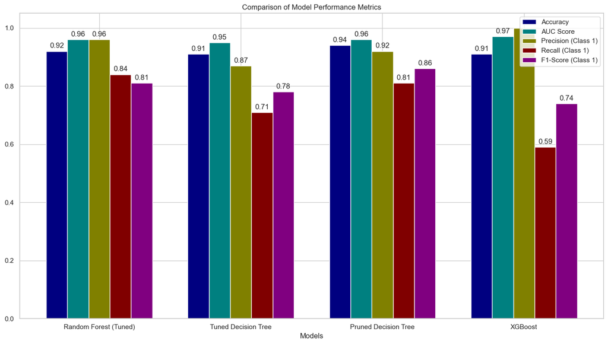

```python
# Defining the data
models = ['Random Forest (Tuned)', 'Tuned Decision Tree', 'Pruned Decision Tree', 'XGBoost']
accuracy = [0.92, 0.91, 0.94, 0.91]
auc_scores = [0.96, 0.95, 0.96, 0.97]
precision = [0.96, 0.87, 0.92, 1.00]  # Precision for class 1
recall = [0.84, 0.71, 0.81, 0.59]  # Recall for class 1
f1_scores = [0.81, 0.78, 0.86, 0.74]  # F1-Score for class 1

x = np.arange(len(models))  # the label locations
width = 0.15  # the width of the bars

fig, ax = plt.subplots(figsize=(14, 8))
rects1 = ax.bar(x - width*2, accuracy, width, label='Accuracy', color='navy')
rects2 = ax.bar(x - width, auc_scores, width, label='AUC Score', color='teal')
rects3 = ax.bar(x, precision, width, label='Precision (Class 1)', color='olive')
rects4 = ax.bar(x + width, recall, width, label='Recall (Class 1)', color='maroon')
rects5 = ax.bar(x + width*2, f1_scores, width, label='F1-Score (Class 1)', color='purple')

# Add some text for labels, title and custom x-axis tick labels, etc.
ax.set_xlabel('Models')
ax.set_title('Comparison of Model Performance Metrics')
ax.set_xticks(x)
ax.set_xticklabels(models)
ax.legend()

ax.bar_label(rects1, padding=3)
ax.bar_label(rects2, padding=3)
ax.bar_label(rects3, padding=3)
ax.bar_label(rects4, padding=3)
ax.bar_label(rects5, padding=3)

fig.tight_layout()

plt.show()
```

Here's a concise interpretation:

Tuned Decision Tree and Pruned Decision Tree models show decent performance, but not as strong as Random Forest. They have lower precision and recall, indicating they may miss more default cases or incorrectly label non-defaulters as defaulters compared to the Random Forest model.

Precision and Recall Trade-off:

XGBoost, despite its excellent AUC, offers the lowest recall suggesting it might be overly cautious about classifying a borrower as a defaulter.

### Overall Suitability

In summary, the choice of model would depend on the specific requirements of your risk management strategy—whether you value accuracy, ability to detect defaulters, or avoiding false alarms the most.

Concluding the exploration and optimization of our loan default prediction model, the Random Forest (Tuned) emerged as the best fit for our objectives, delivering strong performance across all metrics. This model's balanced capabilities make it especially suitable for minimizing risk while maintaining service quality for genuine borrowers.

### **Key Considerations**

- Handling of Missing Data:

Feature Importance of Job Type 'Other': The analysis highlighted that many clients classified under 'Other' in job type were able to meet their loan obligations. This suggests that while job type is significant, its predictive power must be evaluated in combination with other features to avoid biased assessments.

- Use of All Available Data:

By utilizing the entire dataset, including engineered features and interaction terms, the model could leverage complex relationships within the data. This comprehensive use of data helps in better distinguishing between defaulters and non-defaulters.

- Importance of False Positives:

In the financial context, false positives (wrongly predicting default) are particularly critical because denying a loan to a potential non-defaulter could mean a lost opportunity and negative customer impact. The tuned Random Forest model strikes an effective balance, minimizing false positives while maintaining a stringent check against potential defaulters.

- Correlation and Feature Interactions:

The use of a correlation matrix and inclusion of interaction terms such as 'LOAN_TO_VALUE' and 'JOB_OTHER_REASON' were instrumental in understanding how different variables interact with each other and influence the model's predictions.

## **Final Conclusion**

**The Random Forest (Tuned) model, with its nuanced handling of complex data relationships and balanced error management, aligns well with our risk management goals. It ensures robust predictive performance while controlling for the risk of turning away good customers, supporting both our business sustainability and customer satisfaction objectives. This model provides a reliable foundation for making informed lending decisions, optimizing our loan issuance processes, and enhancing financial product offerings.**